# RNA-seq analysis of White and Asian women with breast cancer age over 60 at diagnosis

JietingHu

11/3/2020

setup

```r
#load the library needed for DE analysis
library(limma)
library(Glimma)
library(edgeR)
#I used limma, Glimma, and edgeR (following this vignette: https://bioconductor.org/packages/release/workflows/vignettes/RNAseq123/inst/doc/limmaWorkflow.html)
```

```r
#set the working directory as the same of the files' location
setwd("~/Desktop/final510")
```

data packaging

```r
# I downloaded data from NIH GDC Data Portal, with the selection of White and Asian women, age over 60, breast cancer,  RMA seq HT-seq.counts data in TCGA-BRCA project.
#Reading in count-data( 20 htseq.counts date files for White women age over 60 at diagnosis with breast cancer, 20 htseq.counts date files for Asian women age over 60 at diagnosis).
file <- c("2d721010-840f-4ca7-b41c-6792385b410d.htseq.counts",
          "0a219d18-db73-46e1-a9c9-3565cec06451.htseq.counts",
          "2edcaaa7-63b4-40b4-abbe-5d7a84012e60.htseq.counts",
          "7e56863a-53f2-4c94-9cf0-053d72b4d5ee.htseq.counts",
          "47f0749e-01c7-4d8c-8926-06293c4a9b4e.htseq.counts",
          "91d53a9c-726f-4611-a284-d2b4d659fdd5.htseq.counts",
          "95bae25e-21b8-4b27-a2da-f6ab696f674a.htseq.counts",
          "450cbf36-7dab-46a4-b6b5-d6b99d51083f.htseq.counts",
          "900a1913-f3b7-46ca-88be-c180a5fb5265.htseq.counts",
          "30621023-91a3-4b13-bc10-922491b5f9d3.htseq.counts",
          "95041603-df86-48f7-9ba5-8289883df2d0.htseq.counts",
          "a1a68fe9-9635-4b7f-b9a2-34474ef8c1dc.htseq.counts",
          "ab574ed8-1dcc-437e-9471-7caa4b7fc4a6.htseq.counts",
          "b2a6c9e3-65eb-43bd-849a-5829007379ab.htseq.counts",
          "b71a52ae-68fb-47c3-89da-24a42e947a8c.htseq.counts",
          "de2ffea0-e172-45e2-aa15-f543758deb78.htseq.counts",
          "e9cbd268-573f-41fc-9f17-d25e1d1c9759.htseq.counts",
          "e4544c39-bf5a-4f95-8853-6a59eae4c262.htseq.counts",
          "f4bb4f4b-2e42-4098-9edf-042f1fffea0f.htseq.counts",
          "fb13b1f7-2b62-4cd9-8e01-875acc860016.htseq.counts",
          "a8a58442-78f5-4876-b25e-c04339eb6f26.htseq.counts",
          "45c4eed7-f80d-4d33-abbb-321ff5ed0750.htseq.counts",
          "c14af0e0-81e9-43e7-b08d-b751194e35ef.htseq.counts",
          "7d83af5d-9bcf-4c82-a993-fa9053a9b3cb.htseq.counts",
          "2163b681-ae29-4907-8f15-6c3665eae736.htseq.counts",
          "8a244dd2-0dc1-429c-81a1-5873ce536b47.htseq.counts",
          "48a95042-0ff3-41a6-a447-dc3a64d087fc.htseq.counts",
          "c758cf60-68bc-4154-9d43-44339da29889.htseq.counts",
          "6069387b-32a3-4e1c-8386-050aa2da67c4.htseq.counts",
          "b44cdb13-1812-4bf6-825e-edae5bc5376a.htseq.counts",
          "fa3d5856-e25b-4d4e-94ac-f524dc8a4cf5.htseq.counts",
          "7d229eb4-cdbd-4578-9e54-c7cbd7ef1378.htseq.counts",
          "d4d6abaa-9134-42ac-9adf-2045f747abb4.htseq.counts",
          "d229a59b-4f6c-4714-8dd5-1c714a764b22.htseq.counts",
          "3bb2c361-dc3f-431f-87d1-e2fd1ff4939a.htseq.counts",
          "a8e5861f-e86c-473d-8ff7-5630532b3c61.htseq.counts",
          "36d40974-4d4f-4726-b98f-1ceab329d0bf.htseq.counts",
          "f966cb98-e661-453d-b1ae-aacf5876520a.htseq.counts",
          "0733fd68-9cd5-440a-a849-fb14ef76c00d.htseq.counts",
          "2627073d-a532-4d75-9937-0a4f62df51f9.htseq.counts")
read.delim(file[1], nrow=5)
```

```
##   ENSG00000000003.13 X2995
## 1  ENSG00000000005.5     8
## 2 ENSG00000000419.11  1872
## 3 ENSG00000000457.12  3756
## 4 ENSG00000000460.15  1269
## 5 ENSG00000000938.11   265
```

```r
x <- readDGE(file)
```

```
## Meta tags detected: __no_feature, __ambiguous, __too_low_aQual, __not_aligned, __alignment_not_unique
```

```r
class(x) #this would give class of the dataframe
```

```
## [1] "DGEList"
## attr(,"package")
## [1] "edgeR"
```

```r
dim(x) #this would give dimension of the dataframe
```

```
## [1] 60487    40
```

```r
# The readDGE function in edgeR make it possible for you to effectively read all files and combined them into a matrix of counts for DE analysis.
```

Organising sample information

```r
#I need to list the data and sort it, which I know the order the first 20 is for White and next 20 for Asian women.
samplenames <- substring(colnames(x), 12, nchar(colnames(x)))
samplenames
```

```
##  [1] "0f-4ca7-b41c-6792385b410d.htseq" "73-46e1-a9c9-3565cec06451.htseq"
##  [3] "b4-40b4-abbe-5d7a84012e60.htseq" "f2-4c94-9cf0-053d72b4d5ee.htseq"
##  [5] "c7-4d8c-8926-06293c4a9b4e.htseq" "6f-4611-a284-d2b4d659fdd5.htseq"
##  [7] "b8-4b27-a2da-f6ab696f674a.htseq" "ab-46a4-b6b5-d6b99d51083f.htseq"
##  [9] "b7-46ca-88be-c180a5fb5265.htseq" "a3-4b13-bc10-922491b5f9d3.htseq"
## [11] "86-48f7-9ba5-8289883df2d0.htseq" "35-4b7f-b9a2-34474ef8c1dc.htseq"
## [13] "cc-437e-9471-7caa4b7fc4a6.htseq" "eb-43bd-849a-5829007379ab.htseq"
## [15] "fb-47c3-89da-24a42e947a8c.htseq" "72-45e2-aa15-f543758deb78.htseq"
## [17] "3f-41fc-9f17-d25e1d1c9759.htseq" "5a-4f95-8853-6a59eae4c262.htseq"
## [19] "42-4098-9edf-042f1fffea0f.htseq" "62-4cd9-8e01-875acc860016.htseq"
## [21] "f5-4876-b25e-c04339eb6f26.htseq" "0d-4d33-abbb-321ff5ed0750.htseq"
## [23] "e9-43e7-b08d-b751194e35ef.htseq" "cf-4c82-a993-fa9053a9b3cb.htseq"
## [25] "29-4907-8f15-6c3665eae736.htseq" "c1-429c-81a1-5873ce536b47.htseq"
## [27] "f3-41a6-a447-dc3a64d087fc.htseq" "bc-4154-9d43-44339da29889.htseq"
## [29] "a3-4e1c-8386-050aa2da67c4.htseq" "12-4bf6-825e-edae5bc5376a.htseq"
## [31] "5b-4d4e-94ac-f524dc8a4cf5.htseq" "bd-4578-9e54-c7cbd7ef1378.htseq"
## [33] "34-42ac-9adf-2045f747abb4.htseq" "6c-4714-8dd5-1c714a764b22.htseq"
## [35] "3f-431f-87d1-e2fd1ff4939a.htseq" "6c-473d-8ff7-5630532b3c61.htseq"
## [37] "4f-4726-b98f-1ceab329d0bf.htseq" "61-453d-b1ae-aacf5876520a.htseq"
## [39] "d5-440a-a849-fb14ef76c00d.htseq" "32-4d75-9937-0a4f62df51f9.htseq"
```

Annotate the sample

```r
x$samples
```

```
##                                                                                        files
## 2d721010-840f-4ca7-b41c-6792385b410d.htseq 2d721010-840f-4ca7-b41c-6792385b410d.htseq.counts
## 0a219d18-db73-46e1-a9c9-3565cec06451.htseq 0a219d18-db73-46e1-a9c9-3565cec06451.htseq.counts
## 2edcaaa7-63b4-40b4-abbe-5d7a84012e60.htseq 2edcaaa7-63b4-40b4-abbe-5d7a84012e60.htseq.counts
## 7e56863a-53f2-4c94-9cf0-053d72b4d5ee.htseq 7e56863a-53f2-4c94-9cf0-053d72b4d5ee.htseq.counts
## 47f0749e-01c7-4d8c-8926-06293c4a9b4e.htseq 47f0749e-01c7-4d8c-8926-06293c4a9b4e.htseq.counts
## 91d53a9c-726f-4611-a284-d2b4d659fdd5.htseq 91d53a9c-726f-4611-a284-d2b4d659fdd5.htseq.counts
## 95bae25e-21b8-4b27-a2da-f6ab696f674a.htseq 95bae25e-21b8-4b27-a2da-f6ab696f674a.htseq.counts
## 450cbf36-7dab-46a4-b6b5-d6b99d51083f.htseq 450cbf36-7dab-46a4-b6b5-d6b99d51083f.htseq.counts
## 900a1913-f3b7-46ca-88be-c180a5fb5265.htseq 900a1913-f3b7-46ca-88be-c180a5fb5265.htseq.counts
## 30621023-91a3-4b13-bc10-922491b5f9d3.htseq 30621023-91a3-4b13-bc10-922491b5f9d3.htseq.counts
## 95041603-df86-48f7-9ba5-8289883df2d0.htseq 95041603-df86-48f7-9ba5-8289883df2d0.htseq.counts
## a1a68fe9-9635-4b7f-b9a2-34474ef8c1dc.htseq a1a68fe9-9635-4b7f-b9a2-34474ef8c1dc.htseq.counts
## ab574ed8-1dcc-437e-9471-7caa4b7fc4a6.htseq ab574ed8-1dcc-437e-9471-7caa4b7fc4a6.htseq.counts
## b2a6c9e3-65eb-43bd-849a-5829007379ab.htseq b2a6c9e3-65eb-43bd-849a-5829007379ab.htseq.counts
## b71a52ae-68fb-47c3-89da-24a42e947a8c.htseq b71a52ae-68fb-47c3-89da-24a42e947a8c.htseq.counts
## de2ffea0-e172-45e2-aa15-f543758deb78.htseq de2ffea0-e172-45e2-aa15-f543758deb78.htseq.counts
## e9cbd268-573f-41fc-9f17-d25e1d1c9759.htseq e9cbd268-573f-41fc-9f17-d25e1d1c9759.htseq.counts
## e4544c39-bf5a-4f95-8853-6a59eae4c262.htseq e4544c39-bf5a-4f95-8853-6a59eae4c262.htseq.counts
## f4bb4f4b-2e42-4098-9edf-042f1fffea0f.htseq f4bb4f4b-2e42-4098-9edf-042f1fffea0f.htseq.counts
## fb13b1f7-2b62-4cd9-8e01-875acc860016.htseq fb13b1f7-2b62-4cd9-8e01-875acc860016.htseq.counts
## a8a58442-78f5-4876-b25e-c04339eb6f26.htseq a8a58442-78f5-4876-b25e-c04339eb6f26.htseq.counts
## 45c4eed7-f80d-4d33-abbb-321ff5ed0750.htseq 45c4eed7-f80d-4d33-abbb-321ff5ed0750.htseq.counts
## c14af0e0-81e9-43e7-b08d-b751194e35ef.htseq c14af0e0-81e9-43e7-b08d-b751194e35ef.htseq.counts
## 7d83af5d-9bcf-4c82-a993-fa9053a9b3cb.htseq 7d83af5d-9bcf-4c82-a993-fa9053a9b3cb.htseq.counts
## 2163b681-ae29-4907-8f15-6c3665eae736.htseq 2163b681-ae29-4907-8f15-6c3665eae736.htseq.counts
## 8a244dd2-0dc1-429c-81a1-5873ce536b47.htseq 8a244dd2-0dc1-429c-81a1-5873ce536b47.htseq.counts
## 48a95042-0ff3-41a6-a447-dc3a64d087fc.htseq 48a95042-0ff3-41a6-a447-dc3a64d087fc.htseq.counts
## c758cf60-68bc-4154-9d43-44339da29889.htseq c758cf60-68bc-4154-9d43-44339da29889.htseq.counts
## 6069387b-32a3-4e1c-8386-050aa2da67c4.htseq 6069387b-32a3-4e1c-8386-050aa2da67c4.htseq.counts
## b44cdb13-1812-4bf6-825e-edae5bc5376a.htseq b44cdb13-1812-4bf6-825e-edae5bc5376a.htseq.counts
## fa3d5856-e25b-4d4e-94ac-f524dc8a4cf5.htseq fa3d5856-e25b-4d4e-94ac-f524dc8a4cf5.htseq.counts
## 7d229eb4-cdbd-4578-9e54-c7cbd7ef1378.htseq 7d229eb4-cdbd-4578-9e54-c7cbd7ef1378.htseq.counts
## d4d6abaa-9134-42ac-9adf-2045f747abb4.htseq d4d6abaa-9134-42ac-9adf-2045f747abb4.htseq.counts
## d229a59b-4f6c-4714-8dd5-1c714a764b22.htseq d229a59b-4f6c-4714-8dd5-1c714a764b22.htseq.counts
## 3bb2c361-dc3f-431f-87d1-e2fd1ff4939a.htseq 3bb2c361-dc3f-431f-87d1-e2fd1ff4939a.htseq.counts
## a8e5861f-e86c-473d-8ff7-5630532b3c61.htseq a8e5861f-e86c-473d-8ff7-5630532b3c61.htseq.counts
## 36d40974-4d4f-4726-b98f-1ceab329d0bf.htseq 36d40974-4d4f-4726-b98f-1ceab329d0bf.htseq.counts
## f966cb98-e661-453d-b1ae-aacf5876520a.htseq f966cb98-e661-453d-b1ae-aacf5876520a.htseq.counts
## 0733fd68-9cd5-440a-a849-fb14ef76c00d.htseq 0733fd68-9cd5-440a-a849-fb14ef76c00d.htseq.counts
```

[output cut: 27 more lines]

```
## 8a244dd2-0dc1-429c-81a1-5873ce536b47.htseq     1 111483625            1
## 48a95042-0ff3-41a6-a447-dc3a64d087fc.htseq     1  73063354            1
## c758cf60-68bc-4154-9d43-44339da29889.htseq     1  64422594            1
## 6069387b-32a3-4e1c-8386-050aa2da67c4.htseq     1 104865852            1
## b44cdb13-1812-4bf6-825e-edae5bc5376a.htseq     1 101126853            1
## fa3d5856-e25b-4d4e-94ac-f524dc8a4cf5.htseq     1  95743519            1
## 7d229eb4-cdbd-4578-9e54-c7cbd7ef1378.htseq     1 106759552            1
## d4d6abaa-9134-42ac-9adf-2045f747abb4.htseq     1  74036153            1
## d229a59b-4f6c-4714-8dd5-1c714a764b22.htseq     1  92237990            1
## 3bb2c361-dc3f-431f-87d1-e2fd1ff4939a.htseq     1  72519495            1
## a8e5861f-e86c-473d-8ff7-5630532b3c61.htseq     1 113124232            1
## 36d40974-4d4f-4726-b98f-1ceab329d0bf.htseq     1  80628928            1
## f966cb98-e661-453d-b1ae-aacf5876520a.htseq     1  60098404            1
## 0733fd68-9cd5-440a-a849-fb14ef76c00d.htseq     1  62761703            1
## 2627073d-a532-4d75-9937-0a4f62df51f9.htseq     1  90033440            1
```

Organising gene annotations

```r
samplenames <- substring(colnames(x), 1, nchar(colnames(x)))
samplenames
```

```
##  [1] "2d721010-840f-4ca7-b41c-6792385b410d.htseq"
##  [2] "0a219d18-db73-46e1-a9c9-3565cec06451.htseq"
##  [3] "2edcaaa7-63b4-40b4-abbe-5d7a84012e60.htseq"
##  [4] "7e56863a-53f2-4c94-9cf0-053d72b4d5ee.htseq"
##  [5] "47f0749e-01c7-4d8c-8926-06293c4a9b4e.htseq"
##  [6] "91d53a9c-726f-4611-a284-d2b4d659fdd5.htseq"
##  [7] "95bae25e-21b8-4b27-a2da-f6ab696f674a.htseq"
##  [8] "450cbf36-7dab-46a4-b6b5-d6b99d51083f.htseq"
##  [9] "900a1913-f3b7-46ca-88be-c180a5fb5265.htseq"
## [10] "30621023-91a3-4b13-bc10-922491b5f9d3.htseq"
## [11] "95041603-df86-48f7-9ba5-8289883df2d0.htseq"
## [12] "a1a68fe9-9635-4b7f-b9a2-34474ef8c1dc.htseq"
## [13] "ab574ed8-1dcc-437e-9471-7caa4b7fc4a6.htseq"
## [14] "b2a6c9e3-65eb-43bd-849a-5829007379ab.htseq"
## [15] "b71a52ae-68fb-47c3-89da-24a42e947a8c.htseq"
```

[output cut: 25 more lines]

Specifying which files are for white(w) or Asian women(a)

```r
# Here I specified that the groups corresponding to White and Asian Women in a column.
colnames(x) <- samplenames
group <- c(rep("White",20),rep("Asian",20))
x$samples$group <- group
x$samples
```

```
##                                                                                        files
## 2d721010-840f-4ca7-b41c-6792385b410d.htseq 2d721010-840f-4ca7-b41c-6792385b410d.htseq.counts
## 0a219d18-db73-46e1-a9c9-3565cec06451.htseq 0a219d18-db73-46e1-a9c9-3565cec06451.htseq.counts
## 2edcaaa7-63b4-40b4-abbe-5d7a84012e60.htseq 2edcaaa7-63b4-40b4-abbe-5d7a84012e60.htseq.counts
## 7e56863a-53f2-4c94-9cf0-053d72b4d5ee.htseq 7e56863a-53f2-4c94-9cf0-053d72b4d5ee.htseq.counts
## 47f0749e-01c7-4d8c-8926-06293c4a9b4e.htseq 47f0749e-01c7-4d8c-8926-06293c4a9b4e.htseq.counts
## 91d53a9c-726f-4611-a284-d2b4d659fdd5.htseq 91d53a9c-726f-4611-a284-d2b4d659fdd5.htseq.counts
## 95bae25e-21b8-4b27-a2da-f6ab696f674a.htseq 95bae25e-21b8-4b27-a2da-f6ab696f674a.htseq.counts
## 450cbf36-7dab-46a4-b6b5-d6b99d51083f.htseq 450cbf36-7dab-46a4-b6b5-d6b99d51083f.htseq.counts
## 900a1913-f3b7-46ca-88be-c180a5fb5265.htseq 900a1913-f3b7-46ca-88be-c180a5fb5265.htseq.counts
## 30621023-91a3-4b13-bc10-922491b5f9d3.htseq 30621023-91a3-4b13-bc10-922491b5f9d3.htseq.counts
## 95041603-df86-48f7-9ba5-8289883df2d0.htseq 95041603-df86-48f7-9ba5-8289883df2d0.htseq.counts
## a1a68fe9-9635-4b7f-b9a2-34474ef8c1dc.htseq a1a68fe9-9635-4b7f-b9a2-34474ef8c1dc.htseq.counts
## ab574ed8-1dcc-437e-9471-7caa4b7fc4a6.htseq ab574ed8-1dcc-437e-9471-7caa4b7fc4a6.htseq.counts
## b2a6c9e3-65eb-43bd-849a-5829007379ab.htseq b2a6c9e3-65eb-43bd-849a-5829007379ab.htseq.counts
## b71a52ae-68fb-47c3-89da-24a42e947a8c.htseq b71a52ae-68fb-47c3-89da-24a42e947a8c.htseq.counts
## de2ffea0-e172-45e2-aa15-f543758deb78.htseq de2ffea0-e172-45e2-aa15-f543758deb78.htseq.counts
## e9cbd268-573f-41fc-9f17-d25e1d1c9759.htseq e9cbd268-573f-41fc-9f17-d25e1d1c9759.htseq.counts
## e4544c39-bf5a-4f95-8853-6a59eae4c262.htseq e4544c39-bf5a-4f95-8853-6a59eae4c262.htseq.counts
## f4bb4f4b-2e42-4098-9edf-042f1fffea0f.htseq f4bb4f4b-2e42-4098-9edf-042f1fffea0f.htseq.counts
## fb13b1f7-2b62-4cd9-8e01-875acc860016.htseq fb13b1f7-2b62-4cd9-8e01-875acc860016.htseq.counts
## a8a58442-78f5-4876-b25e-c04339eb6f26.htseq a8a58442-78f5-4876-b25e-c04339eb6f26.htseq.counts
## 45c4eed7-f80d-4d33-abbb-321ff5ed0750.htseq 45c4eed7-f80d-4d33-abbb-321ff5ed0750.htseq.counts
## c14af0e0-81e9-43e7-b08d-b751194e35ef.htseq c14af0e0-81e9-43e7-b08d-b751194e35ef.htseq.counts
## 7d83af5d-9bcf-4c82-a993-fa9053a9b3cb.htseq 7d83af5d-9bcf-4c82-a993-fa9053a9b3cb.htseq.counts
## 2163b681-ae29-4907-8f15-6c3665eae736.htseq 2163b681-ae29-4907-8f15-6c3665eae736.htseq.counts
## 8a244dd2-0dc1-429c-81a1-5873ce536b47.htseq 8a244dd2-0dc1-429c-81a1-5873ce536b47.htseq.counts
## 48a95042-0ff3-41a6-a447-dc3a64d087fc.htseq 48a95042-0ff3-41a6-a447-dc3a64d087fc.htseq.counts
## c758cf60-68bc-4154-9d43-44339da29889.htseq c758cf60-68bc-4154-9d43-44339da29889.htseq.counts
## 6069387b-32a3-4e1c-8386-050aa2da67c4.htseq 6069387b-32a3-4e1c-8386-050aa2da67c4.htseq.counts
## b44cdb13-1812-4bf6-825e-edae5bc5376a.htseq b44cdb13-1812-4bf6-825e-edae5bc5376a.htseq.counts
## fa3d5856-e25b-4d4e-94ac-f524dc8a4cf5.htseq fa3d5856-e25b-4d4e-94ac-f524dc8a4cf5.htseq.counts
## 7d229eb4-cdbd-4578-9e54-c7cbd7ef1378.htseq 7d229eb4-cdbd-4578-9e54-c7cbd7ef1378.htseq.counts
## d4d6abaa-9134-42ac-9adf-2045f747abb4.htseq d4d6abaa-9134-42ac-9adf-2045f747abb4.htseq.counts
## d229a59b-4f6c-4714-8dd5-1c714a764b22.htseq d229a59b-4f6c-4714-8dd5-1c714a764b22.htseq.counts
## 3bb2c361-dc3f-431f-87d1-e2fd1ff4939a.htseq 3bb2c361-dc3f-431f-87d1-e2fd1ff4939a.htseq.counts
## a8e5861f-e86c-473d-8ff7-5630532b3c61.htseq a8e5861f-e86c-473d-8ff7-5630532b3c61.htseq.counts
## 36d40974-4d4f-4726-b98f-1ceab329d0bf.htseq 36d40974-4d4f-4726-b98f-1ceab329d0bf.htseq.counts
## f966cb98-e661-453d-b1ae-aacf5876520a.htseq f966cb98-e661-453d-b1ae-aacf5876520a.htseq.counts
## 0733fd68-9cd5-440a-a849-fb14ef76c00d.htseq 0733fd68-9cd5-440a-a849-fb14ef76c00d.htseq.counts
```

[output cut: 27 more lines]

```
## 8a244dd2-0dc1-429c-81a1-5873ce536b47.htseq Asian 111483625            1
## 48a95042-0ff3-41a6-a447-dc3a64d087fc.htseq Asian  73063354            1
## c758cf60-68bc-4154-9d43-44339da29889.htseq Asian  64422594            1
## 6069387b-32a3-4e1c-8386-050aa2da67c4.htseq Asian 104865852            1
## b44cdb13-1812-4bf6-825e-edae5bc5376a.htseq Asian 101126853            1
## fa3d5856-e25b-4d4e-94ac-f524dc8a4cf5.htseq Asian  95743519            1
## 7d229eb4-cdbd-4578-9e54-c7cbd7ef1378.htseq Asian 106759552            1
## d4d6abaa-9134-42ac-9adf-2045f747abb4.htseq Asian  74036153            1
## d229a59b-4f6c-4714-8dd5-1c714a764b22.htseq Asian  92237990            1
## 3bb2c361-dc3f-431f-87d1-e2fd1ff4939a.htseq Asian  72519495            1
## a8e5861f-e86c-473d-8ff7-5630532b3c61.htseq Asian 113124232            1
## 36d40974-4d4f-4726-b98f-1ceab329d0bf.htseq Asian  80628928            1
## f966cb98-e661-453d-b1ae-aacf5876520a.htseq Asian  60098404            1
## 0733fd68-9cd5-440a-a849-fb14ef76c00d.htseq Asian  62761703            1
## 2627073d-a532-4d75-9937-0a4f62df51f9.htseq Asian  90033440            1
```

load library for human

```r
# The analysis is for human so change the library as to human.
library(Homo.sapiens)
library(gsubfn)
# It has been noticed that ENSEMBL gene names with decimal are not recognized, so it is removed.
geneid <- rownames(x)
geneid <- gsub("\\.[0-9]*$", "", geneid) #remove decimals and numbers after decimals
genes <- select(Homo.sapiens, keys=geneid, columns=c("SYMBOL", "TXCHROM"),
                keytype="ENSEMBL")
# This will return the first few rows of genes with ENSEMBL names, SYMBOL and TXCHROM.
head(genes)
```

```
##           ENSEMBL   SYMBOL TXCHROM
## 1 ENSG00000000005     TNMD    chrX
## 2 ENSG00000000419     DPM1   chr20
## 3 ENSG00000000457    SCYL3    chr1
## 4 ENSG00000000460 C1orf112    chr1
## 5 ENSG00000000938      FGR    chr1
## 6 ENSG00000000971      CFH    chr1
```

remove duplicated genes

```r
genes <- genes[!duplicated(genes$ENSEMBL),]
```

DGEList-object containing raw count data with associated sample information and gene annotations

```r
x$genes <- genes
x
```

```
## An object of class "DGEList"
## $samples
##                                                                                        files
## 2d721010-840f-4ca7-b41c-6792385b410d.htseq 2d721010-840f-4ca7-b41c-6792385b410d.htseq.counts
## 0a219d18-db73-46e1-a9c9-3565cec06451.htseq 0a219d18-db73-46e1-a9c9-3565cec06451.htseq.counts
## 2edcaaa7-63b4-40b4-abbe-5d7a84012e60.htseq 2edcaaa7-63b4-40b4-abbe-5d7a84012e60.htseq.counts
## 7e56863a-53f2-4c94-9cf0-053d72b4d5ee.htseq 7e56863a-53f2-4c94-9cf0-053d72b4d5ee.htseq.counts
## 47f0749e-01c7-4d8c-8926-06293c4a9b4e.htseq 47f0749e-01c7-4d8c-8926-06293c4a9b4e.htseq.counts
##                                            group lib.size norm.factors
## 2d721010-840f-4ca7-b41c-6792385b410d.htseq White 72584913            1
## 0a219d18-db73-46e1-a9c9-3565cec06451.htseq White 85098293            1
## 2edcaaa7-63b4-40b4-abbe-5d7a84012e60.htseq White 67908861            1
## 7e56863a-53f2-4c94-9cf0-053d72b4d5ee.htseq White 69901382            1
## 47f0749e-01c7-4d8c-8926-06293c4a9b4e.htseq White 86309112            1
## 35 more rows ...
##
## $counts
##                     Samples
## Tags                 2d721010-840f-4ca7-b41c-6792385b410d.htseq
##   ENSG00000000005.5                                           8
##   ENSG00000000419.11                                       1872
##   ENSG00000000457.12                                       3756
##   ENSG00000000460.15                                       1269
##   ENSG00000000938.11                                        265
##                     Samples
## Tags                 0a219d18-db73-46e1-a9c9-3565cec06451.htseq
##   ENSG00000000005.5                                          36
##   ENSG00000000419.11                                       2144
##   ENSG00000000457.12                                       6955
##   ENSG00000000460.15                                       1343
##   ENSG00000000938.11                                        555
##                     Samples
## Tags                 2edcaaa7-63b4-40b4-abbe-5d7a84012e60.htseq
##   ENSG00000000005.5                                           5
##   ENSG00000000419.11                                       1695
##   ENSG00000000457.12                                       1930
##   ENSG00000000460.15                                        463
##   ENSG00000000938.11                                        336
##                     Samples
## Tags                 7e56863a-53f2-4c94-9cf0-053d72b4d5ee.htseq
```

[output cut: 252 more lines]

```
##   ENSG00000000005.5                                           2
##   ENSG00000000419.11                                       1021
##   ENSG00000000457.12                                        632
##   ENSG00000000460.15                                        212
##   ENSG00000000938.11                                         92
## 60482 more rows ...
##
## $genes
##           ENSEMBL   SYMBOL TXCHROM
## 1 ENSG00000000005     TNMD    chrX
## 2 ENSG00000000419     DPM1   chr20
## 3 ENSG00000000457    SCYL3    chr1
## 4 ENSG00000000460 C1orf112    chr1
## 5 ENSG00000000938      FGR    chr1
## 60482 more rows ...
```

```r
## This will give you gene annotations + raw count data + sample information.
```

data preprocessing

```r
#Transformations from the raw-scale
# This way the raw counts are converted to CPM (counts per million) and LCPM (log-CPM) values using the cpm function in edgeR
cpm <- cpm(x)
lcpm <- cpm(x, log=TRUE)
L <- mean(x$samples$lib.size) * 1e-6
M <- median(x$samples$lib.size) * 1e-6
c(L, M)
```

```
## [1] 86.18766 84.30155
```

```r
summary(lcpm)
```

```
##  2d721010-840f-4ca7-b41c-6792385b410d.htseq
##  Min.   :-5.4294
##  1st Qu.:-5.4294
##  Median :-5.4294
##  Mean   :-2.5220
##  3rd Qu.:-0.2583
##  Max.   :17.4649
##  0a219d18-db73-46e1-a9c9-3565cec06451.htseq
##  Min.   :-5.429
##  1st Qu.:-5.429
##  Median :-4.838
##  Mean   :-2.332
##  3rd Qu.: 0.261
##  Max.   :17.465
##  2edcaaa7-63b4-40b4-abbe-5d7a84012e60.htseq
##  Min.   :-5.42941
##  1st Qu.:-5.42941
##  Median :-4.72049
##  Mean   :-2.46431
##  3rd Qu.:-0.05044
##  Max.   :17.67284
##  7e56863a-53f2-4c94-9cf0-053d72b4d5ee.htseq
##  Min.   :-5.42941
##  1st Qu.:-5.42941
##  Median :-4.73654
##  Mean   :-2.43641
##  3rd Qu.: 0.09428
##  Max.   :17.57828
##  47f0749e-01c7-4d8c-8926-06293c4a9b4e.htseq
##  Min.   :-5.4294
##  1st Qu.:-5.4294
##  Median :-4.8451
##  Mean   :-2.3487
##  3rd Qu.: 0.3368
##  Max.   :17.4980
##  91d53a9c-726f-4611-a284-d2b4d659fdd5.htseq
##  Min.   :-5.4294
##  1st Qu.:-5.4294
##  Median :-4.8380
##  Mean   :-2.6413
```

[output cut: 225 more lines]

```
##  Max.   :17.5272
##  0733fd68-9cd5-440a-a849-fb14ef76c00d.htseq
##  Min.   :-5.4294
##  1st Qu.:-5.4294
##  Median :-5.4294
##  Mean   :-2.6163
##  3rd Qu.:-0.4033
##  Max.   :17.8483
##  2627073d-a532-4d75-9937-0a4f62df51f9.htseq
##  Min.   :-5.429
##  1st Qu.:-5.429
##  Median :-5.429
##  Mean   :-3.051
##  3rd Qu.:-1.630
##  Max.   :19.250
```

```r
# this gives a summary table of all the data including  Min.,Mean, Max and so on.
```

Removing genes that are lowly expressed

```r
table(rowSums(x$counts==0)==9)
```

```
##
## FALSE  TRUE
## 59984   503
```

Filter genes and keep approprite ones

```r
#This step I try to calculate the significance threshold for read counts and to use that threshold to filter the data.
keep.exprs <- filterByExpr(x, group=group)
x <- x[keep.exprs,, keep.lib.sizes=FALSE]
dim(x)
```

```
## [1] 21009    40
```

Plot the density of log-CPM values for raw and filtered data

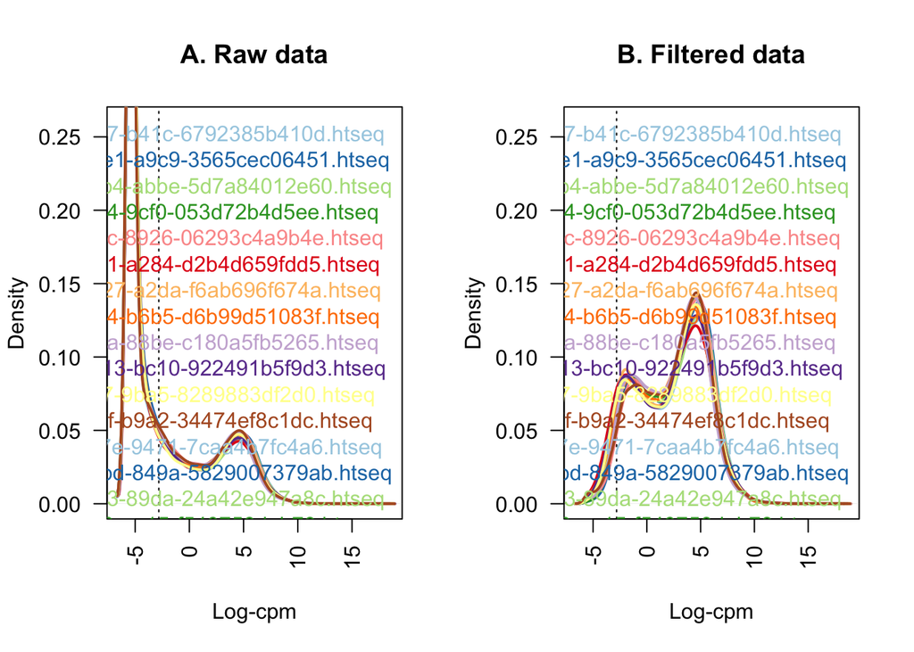

```r
# this step is to plot raw vs. filtered data
lcpm.cutoff <- log2(10/M + 2/L)
library(RColorBrewer)
nsamples <- ncol(x)
col <- brewer.pal(nsamples, "Paired")
par(mfrow=c(1,2))
plot(density(lcpm[,1]), col=col[1], lwd=2, ylim=c(0,0.26), las=2, main="", xlab="")
title(main="A. Raw data", xlab="Log-cpm")
abline(v=lcpm.cutoff, lty=3)
for (i in 2:nsamples){
den <- density(lcpm[,i])
lines(den$x, den$y, col=col[i], lwd=2)
}
legend("topright", samplenames, text.col=col, bty="n")
lcpm <- cpm(x, log=TRUE)
plot(density(lcpm[,1]), col=col[1], lwd=2, ylim=c(0,0.26), las=2, main="", xlab="")
title(main="B. Filtered data", xlab="Log-cpm")
abline(v=lcpm.cutoff, lty=3)
for (i in 2:nsamples){
den <- density(lcpm[,i])
lines(den$x, den$y, col=col[i], lwd=2)
}
legend("topright", samplenames, text.col=col, bty="n")
```

this above two Figures are density of log-CPM values for raw pre-filtered data A and post-filtered data B. The dotted black verticle line is log-CPM threshold. The trendlines all overlap in B and the overall shape of the filtered data is bimodal. We care mostly about the right peak of log-cpm = 5.

Normalising gene expression distributions

```r
#This is the trimmed mean of M-values” (TMM) method of normalization (Robinson and Oshlack 2010) using the calcNormFactors function in edgeR
x <- calcNormFactors(x, method = "TMM")
x$samples$norm.factors
```

```
##  [1] 1.1324412 1.2352272 1.1120837 1.1162529 1.1862128 0.9176949 1.0134804
##  [8] 0.9103105 0.9959858 0.9978204 1.0280524 1.0609415 0.9468067 1.2078285
## [15] 1.1209583 0.9258006 0.9883036 0.9043272 1.1636518 0.9687432 0.8089006
## [22] 1.0848667 0.9824723 1.0240388 1.1114568 0.6101718 0.9231349 1.1631162
## [29] 1.0768104 1.0093385 1.0728997 1.0206979 0.8827149 1.1560151 1.0535583
## [36] 1.0356354 1.0943522 1.0943691 0.9694146 0.4472851
```

give a better visual representation of the effects of normalisation

```r
#duplicating the data, then adjusting it so that the counts of the first sample are reduced to 5% of their original values, while the counts of the second sample are inflated to be 5-times larger
x2 <- x
x2$samples$norm.factors <- 1
x2$counts[,1] <- ceiling(x2$counts[,1]*0.05)
x2$counts[,2] <- x2$counts[,2]*5
```

boxplot presentation

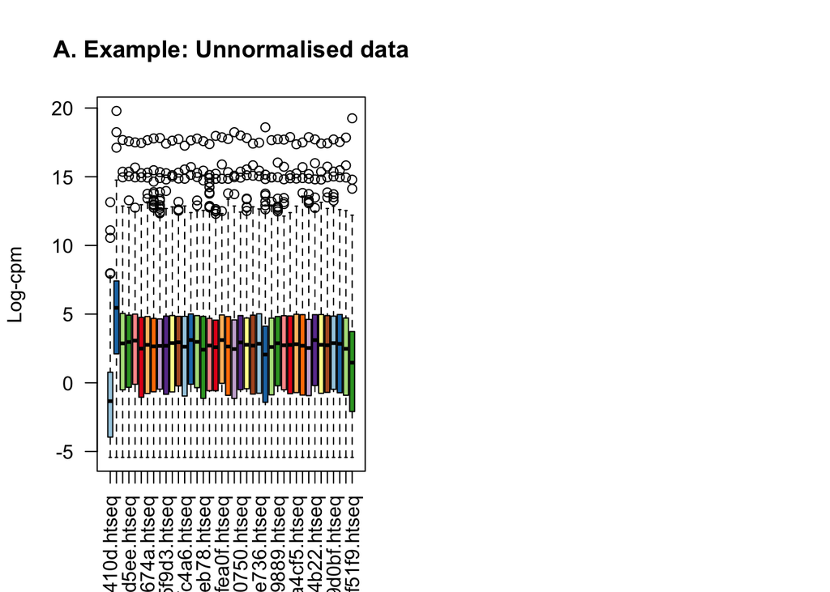

```r
par(mfrow=c(1,2))
lcpm <- cpm(x2, log=TRUE)
boxplot(lcpm, las=2, col=col, main="")
title(main="A. Example: Unnormalised data",ylab="Log-cpm")
```

```r
x2 <- calcNormFactors(x2)
x2$samples$norm.factors
```

```
##  [1] 0.06739859 6.33422455 1.17205738 1.14886024 1.23956077 0.93291404
##  [7] 1.04120696 0.96038102 0.97732977 1.02282524 1.06662379 1.12076593
## [13] 1.00546679 1.23385386 1.14683093 0.96189748 0.99522247 0.90324537
## [19] 1.23639652 1.03217771 0.82627873 1.09964067 0.99634136 1.12691867
## [25] 1.16926135 0.61895109 0.92567332 1.14453967 1.10996872 1.02840147
## [31] 1.09038778 1.10161644 0.89383664 1.20122657 1.08473518 1.08467201
## [37] 1.11012289 1.14633239 0.99045723 0.46950581
```

Boxplot expression for normalised data

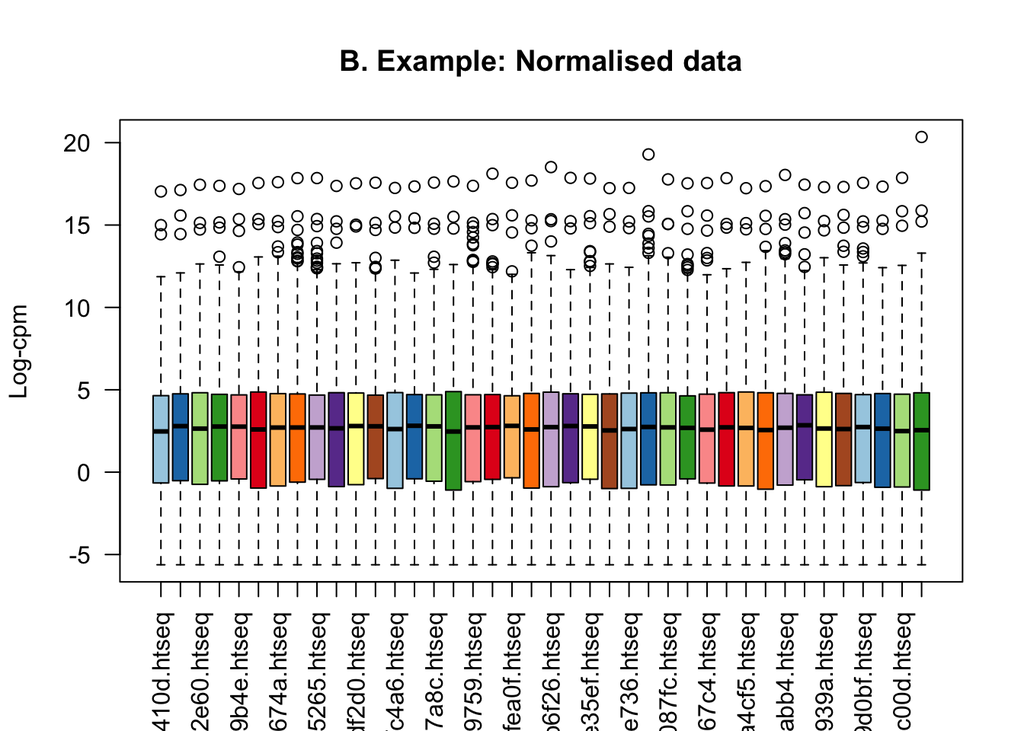

```r
lcpm <- cpm(x2, log=TRUE)
boxplot(lcpm, las=2, col=col, main="")
title(main="B. Example: Normalised data",ylab="Log-cpm")
```

Unsupervised clustering of samples using multi-dimensional scaling (MDS) plot

```r
lcpm <- cpm(x, log=TRUE)
par(mfrow=c(1,2))
group
```

```
##  [1] "White" "White" "White" "White" "White" "White" "White" "White" "White"
## [10] "White" "White" "White" "White" "White" "White" "White" "White" "White"
## [19] "White" "White" "Asian" "Asian" "Asian" "Asian" "Asian" "Asian" "Asian"
## [28] "Asian" "Asian" "Asian" "Asian" "Asian" "Asian" "Asian" "Asian" "Asian"
## [37] "Asian" "Asian" "Asian" "Asian"
```

```r
levels(group) <-  brewer.pal(nlevels(group), "Set1")
```

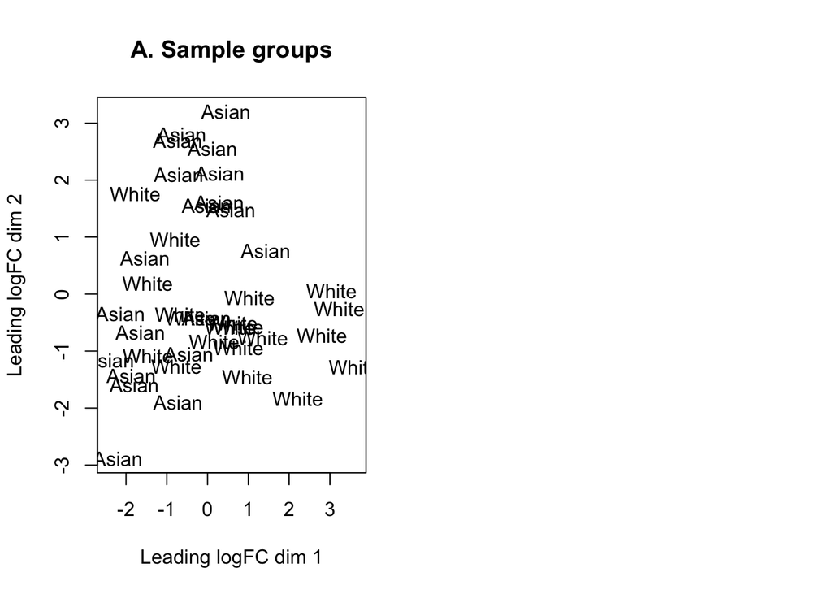

```r
col.group <- as.character(group)
col.group <- c("purple","orange")[group]
plotMDS(lcpm, labels=group, col=col.group)
title(main="A. Sample groups")
```

```r
#Glimma plot
glMDSPlot(lcpm, groups=group)
```

Differential expression analysis

```r
#Creating a design matrix and contrasts
design <- model.matrix(~0+group)
colnames(design) <- gsub("group", "", colnames(design))
design
```

```
##    Asian White
## 1      0     1
## 2      0     1
## 3      0     1
## 4      0     1
## 5      0     1
## 6      0     1
## 7      0     1
## 8      0     1
## 9      0     1
## 10     0     1
## 11     0     1
## 12     0     1
## 13     0     1
## 14     0     1
```

[output cut: 31 more lines]

contrast matrix

```r
contr.matrix <- makeContrasts(
   WhitevsAsian = White-Asian,
   levels = colnames(design))
contr.matrix
```

```
##        Contrasts
## Levels  WhitevsAsian
##   Asian           -1
##   White            1
```

Removing heteroscedascity from count data

```
## An object of class "EList"
## $genes
##           ENSEMBL   SYMBOL TXCHROM
## 1 ENSG00000000005     TNMD    chrX
## 2 ENSG00000000419     DPM1   chr20
## 3 ENSG00000000457    SCYL3    chr1
## 4 ENSG00000000460 C1orf112    chr1
## 5 ENSG00000000938      FGR    chr1
## 21004 more rows ...
##
## $targets
##                                                                                        files
## 2d721010-840f-4ca7-b41c-6792385b410d.htseq 2d721010-840f-4ca7-b41c-6792385b410d.htseq.counts
## 0a219d18-db73-46e1-a9c9-3565cec06451.htseq 0a219d18-db73-46e1-a9c9-3565cec06451.htseq.counts
## 2edcaaa7-63b4-40b4-abbe-5d7a84012e60.htseq 2edcaaa7-63b4-40b4-abbe-5d7a84012e60.htseq.counts
## 7e56863a-53f2-4c94-9cf0-053d72b4d5ee.htseq 7e56863a-53f2-4c94-9cf0-053d72b4d5ee.htseq.counts
## 47f0749e-01c7-4d8c-8926-06293c4a9b4e.htseq 47f0749e-01c7-4d8c-8926-06293c4a9b4e.htseq.counts
##                                            group  lib.size norm.factors
## 2d721010-840f-4ca7-b41c-6792385b410d.htseq White  82047551     1.132441
## 0a219d18-db73-46e1-a9c9-3565cec06451.htseq White 105021389     1.235227
## 2edcaaa7-63b4-40b4-abbe-5d7a84012e60.htseq White  75432161     1.112084
## 7e56863a-53f2-4c94-9cf0-053d72b4d5ee.htseq White  77967554     1.116253
## 47f0749e-01c7-4d8c-8926-06293c4a9b4e.htseq White 102251578     1.186213
## 35 more rows ...
##
## $E
##                     Samples
## Tags                 2d721010-840f-4ca7-b41c-6792385b410d.htseq
##   ENSG00000000005.5                                   -3.270926
##   ENSG00000000419.11                                   4.512362
##   ENSG00000000457.12                                   5.516785
##   ENSG00000000460.15                                   3.951656
##   ENSG00000000938.11                                   1.694180
##                     Samples
## Tags                 0a219d18-db73-46e1-a9c9-3565cec06451.htseq
##   ENSG00000000005.5                                   -1.524715
##   ENSG00000000419.11                                   4.351886
##   ENSG00000000457.12                                   6.049399
##   ENSG00000000460.15                                   3.677241
##   ENSG00000000938.11                                   2.403104
```

[output cut: 300 more lines]

```
## [1,] 0.4980476 0.4734174 0.4648302 0.4648302 0.4648302
## [2,] 2.5714417 2.4808714 2.3352931 2.2878181 1.9981358
## [3,] 2.4567850 2.3094391 2.1129590 2.0536315 1.7416801
## [4,] 1.9120451 1.6982957 1.4915784 1.4412953 1.2211716
## [5,] 1.5577975 1.3771781 1.2267690 1.1922081 1.0411776
## 21004 more rows ...
##
## $design
##   Asian White
## 1     0     1
## 2     0     1
## 3     0     1
## 4     0     1
## 5     0     1
## 35 more rows ...
```

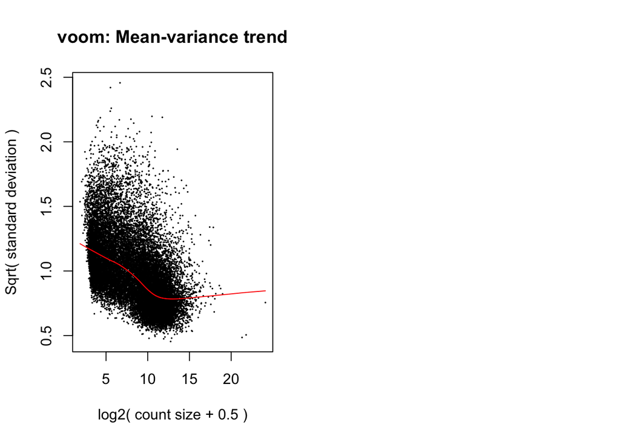

```r
par(mfrow=c(1,2))
v <- voom(x, design, plot=TRUE)
v
```

The above figure is the result of voom function extracts residual variances from fitting linear models to log-CPM transformed data. Means on the x-axis and variances on the y-axis of each genes are plotted to show the dependence between the two before the voom function is applied to the data.

Apply voom precision weights to data

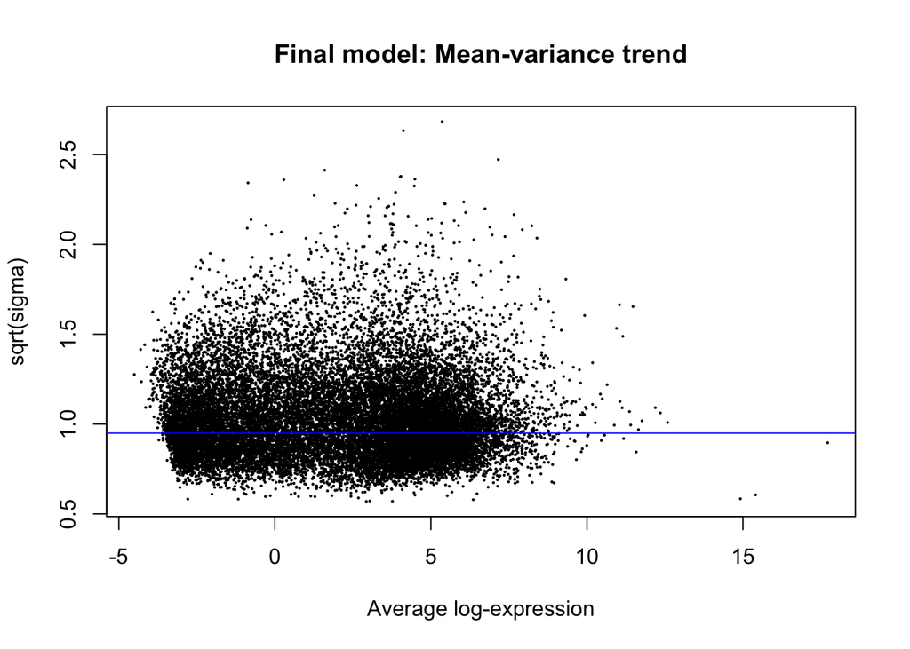

```r
vfit <- lmFit(v, design)
vfit <- contrasts.fit(vfit, contrasts=contr.matrix)
efit <- eBayes(vfit)
plotSA(efit, main="Final model: Mean-variance trend")
```

This above figure is the final model of mean and variance trend with average log-expression on the x-axis and sqrt(sigma) on the y-axis.

Examining the number of DE genes

```r
summary(decideTests(efit))
```

```
##        WhitevsAsian
## Down            627
## NotSig        19689
## Up              693
```

```r
#set lfc = 0.5 and see the result
#use the treat method (McCarthy and Smyth 2009) can be used to calculate p-values from empirical Bayes moderated t-statistics with a minimum log-FC requirement
tfit <- treat(vfit, lfc=0.5)
dt <- decideTests(tfit)
summary(dt)
```

```
##        WhitevsAsian
## Down              1
## NotSig        21001
## Up                7
```

```r
#extract DE genes in multiple comparison
de.common <- which(dt[,1]!=0)
length(de.common)
```

```
## [1] 8
```

```r
head(tfit$genes$SYMBOL[de.common], n=20)
```

```
## [1] "UTS2"     "OGN"      "MMP27"    "SCN2B"    "CCDC144A" "FAM106C"  NA
## [8] NA
```

Make Venn Diagram

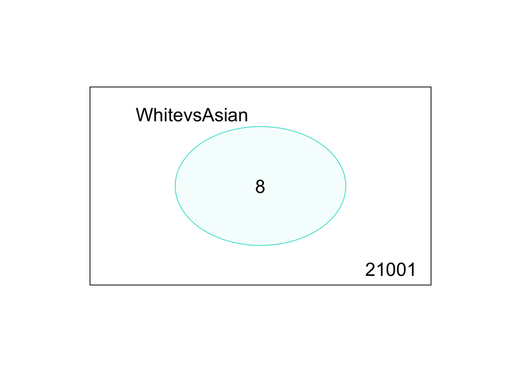

```r
vennDiagram(dt[,1], circle.col=c("turquoise", "salmon"))
```

This Venn diagram shows 8 DE genes in White vs. Asian women genes.

extract the result to a file

```r
write.fit(tfit, dt, file="results.txt")
```

examnine the DE gene

```r
#topTreat function to lists top DE genes
White.vs.Asian <- topTreat(tfit, coef=1, n=Inf)
head(White.vs.Asian)
```

```
##                            ENSEMBL   SYMBOL TXCHROM     logFC   AveExpr
## ENSG00000239830.1  ENSG00000239830     <NA>    <NA>  4.556581 -2.010703
## ENSG00000207425.1  ENSG00000207425     <NA>    <NA>  4.636772 -3.530407
## ENSG00000049247.12 ENSG00000049247     UTS2    chr1 -3.566794 -2.638914
## ENSG00000170160.15 ENSG00000170160 CCDC144A   chr17  3.646803 -2.785451
## ENSG00000106809.9  ENSG00000106809      OGN    chr9  3.721928  2.694393
## ENSG00000137675.4  ENSG00000137675    MMP27   chr11  3.164236 -3.547928
##                            t      P.Value    adj.P.Val
## ENSG00000239830.1  12.779770 2.370566e-16 4.980323e-12
## ENSG00000207425.1   5.922321 2.607991e-07 2.739565e-03
## ENSG00000049247.12 -5.604079 7.413705e-07 4.699227e-03
## ENSG00000170160.15  5.547191 8.947073e-07 4.699227e-03
## ENSG00000106809.9   5.189815 2.895071e-06 1.155600e-02
## ENSG00000137675.4   5.112247 3.716819e-06 1.155600e-02
```

Useful graphical representations of differential expression results

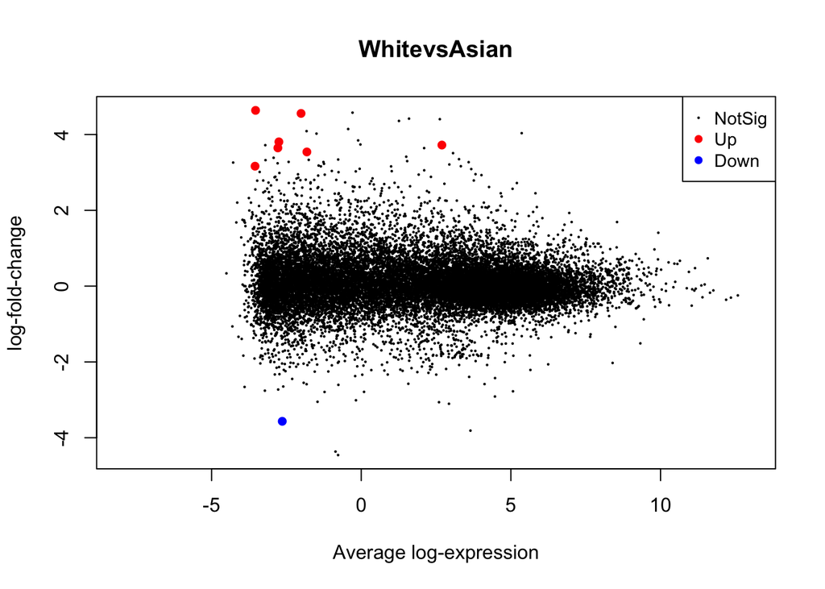

```r
# make a mean-difference (MD) plot
plotMD(tfit, column=1, status=dt[,1], main=colnames(tfit)[1],
       xlim=c(-8,13))
```

This is a MD plot displays log-FCs from the linear model fit against average log-CPM values. The DE genes are highlighted in red for upregulation and blue for downregulation.